# Sentiment_Analysis_TVShows

## Problem Statement

What makes Family Guy animated show stand out from other animated comedy TV shows? The goals is to look at transcripts of various animated comedy TV shows and note their similarities and differences. Specifically, I'd like to know if Family Guy animated comedy show is different than other animated comedy TV shows, since it is the show that got me interested in animated comedy TV shows.

## Data Gathering

To decide which animated comedy shows to look into, I went to IMDB and looked specifically at the best animated comedy TV shows. To narrow it down further, I looked only at those with greater than a 7/10 rating and more than 50,000 votes. *The source was IMDB to find the top 10 popular animated comedy TV shows.*

The list of top 10 animated comedy TV shows was sorted by Popularity:

1. Family Guy
2. The Simpsons
3. Rick and Morty
4. King of the Hill
5. Bob's Burgers
6. South Park
7. BoJack Horseman
8. American Dad!
9. Archer
10. Futurama

## Importing libraries

```python
import requests
from bs4 import BeautifulSoup
import pandas as pd
import numpy as np
import re
import string
import matplotlib.pyplot as plt
from sklearn.feature_extraction.text import CountVectorizer
from collections import Counter
from wordcloud import WordCloud
from sklearn.feature_extraction import text
from textblob import TextBlob
```

## Data Collection

```python
#web scraping
def url_to_transcript(url):
    page = requests.get(url).text
    soup = BeautifulSoup(page, "lxml")
    text = [p.text for p in soup.find(class_ = "postbody"'').find_all('p')]
    return text

urls_family_guy = ["https://transcripts.foreverdreaming.org/viewtopic.php?f=430&t=21132",
                  "https://transcripts.foreverdreaming.org/viewtopic.php?f=430&t=21140",
                  "https://transcripts.foreverdreaming.org/viewtopic.php?f=430&t=21164",
                  "https://transcripts.foreverdreaming.org/viewtopic.php?f=430&t=21202",
                  "https://transcripts.foreverdreaming.org/viewtopic.php?f=430&t=21218"]

urls_simpsons = ["https://transcripts.foreverdreaming.org/viewtopic.php?f=431&t=21865",
                "https://transcripts.foreverdreaming.org/viewtopic.php?f=431&t=21884",
                "https://transcripts.foreverdreaming.org/viewtopic.php?f=431&t=21899",
                "https://transcripts.foreverdreaming.org/viewtopic.php?f=431&t=21928",
                "https://transcripts.foreverdreaming.org/viewtopic.php?f=431&t=21946"]

urls_rick = ["https://transcripts.foreverdreaming.org/viewtopic.php?f=364&t=19383",
            "https://transcripts.foreverdreaming.org/viewtopic.php?f=364&t=19965",
            "https://transcripts.foreverdreaming.org/viewtopic.php?f=364&t=32126",
            "https://transcripts.foreverdreaming.org/viewtopic.php?f=364&t=36594",
            "https://transcripts.foreverdreaming.org/viewtopic.php?f=364&t=45819"]

urls_burger = ["https://transcripts.foreverdreaming.org/viewtopic.php?f=428&t=20912",
              "https://transcripts.foreverdreaming.org/viewtopic.php?f=428&t=20931",
              "https://transcripts.foreverdreaming.org/viewtopic.php?f=428&t=20945",
              "https://transcripts.foreverdreaming.org/viewtopic.php?f=428&t=20968",
              "https://transcripts.foreverdreaming.org/viewtopic.php?f=428&t=20980"]

urls_futurama = ["https://transcripts.foreverdreaming.org/viewtopic.php?f=1223&t=62143",
                "https://transcripts.foreverdreaming.org/viewtopic.php?f=1223&t=61715",
                "https://transcripts.foreverdreaming.org/viewtopic.php?f=1223&t=62352",
                "https://transcripts.foreverdreaming.org/viewtopic.php?f=1223&t=62530",
                "https://transcripts.foreverdreaming.org/viewtopic.php?f=1223&t=64786"]

tv_shows = ['family_guy', 'the_simpsons', 'rick_and_morty', 'bob_burger', 'futurama']
```

```python
transcripts_family_guy = [url_to_transcript(u) for u in urls_family_guy]
transcripts_simpsons = [url_to_transcript(u) for u in urls_simpsons]
transcripts_rick = [url_to_transcript(u) for u in urls_rick]
transcripts_burger = [url_to_transcript(u) for u in urls_burger]
transcripts_futurama = [url_to_transcript(u) for u in urls_futurama]
```

```python
data_dict = {'Family Guy':transcripts_family_guy,
            'The Simpsons':transcripts_simpsons,
            'Rick And Morty':transcripts_rick,
            'Bob Burger':transcripts_burger,
            'Futurama':transcripts_futurama}
data_dict.keys()
```

```
dict_keys(['Family Guy', 'The Simpsons', 'Rick And Morty', 'Bob Burger', 'Futurama'])
```

```python
def combine_text(list_of_text):
    combined_text = ' '.join(str(v) for v in list_of_text)
    return combined_text
```

```python
data_combined = {key: [combine_text(value)] for (key, value) in data_dict.items()}
```

```python
pd.set_option('max_colwidth', 150)

data_df = pd.DataFrame.from_dict(data_combined).transpose()
data_df.columns = ['transcript']
data_df = data_df.sort_index()
data_df
```

|  | transcript |
| --- | --- |
| Bob Burger | ['[plays back chewing]', 'Gene.', '[adds reverb]', 'Gene. Gene.', '[burps] what?', 'Stop.', 'Bob, no more newspaper, please.', 'My parents are gon... |
| Family Guy | ["Lois: [Singing] ♪ It seems today that all you see ♪\n♪ is violence in movies and sex on TV. ♪\n♪ But where are those good old-fashioned values ♪... |
| Futurama | ['This place was a great choice.', 'The food is amazing.', 'And such generous portions.', 'If you liked the meal...', 'just wait till you try\nthe... |
| Rick And Morty | ['Run!', 'Morty, do it! Hit the button now!', "I can't do it, Rick! They're my parents and sister!", "Morty, I already told you it's not your fami... |
| The Simpsons | ['Inside, HOMER opens an oven.', 'HOMER: Do I smell cupcakes? Ooh, do I ever!', "MARGE: Uh-uh, Homer. Lisa's making these for her teacher.", 'HO... |

## Data Cleaning

```python
def clean_text_round1(text):
    text = text.lower()
    text = re.sub('[.*?]', '', text)
    text = re.sub('[%s]' % re.escape(string.punctuation), '', text)
    text = re.sub('\w*\d\w*', '', text)
    return text

round1 = lambda x: clean_text_round1(x)
```

```python
data_clean = pd.DataFrame(data_df.transcript.apply(round1))
data_clean
```

|  | transcript |
| --- | --- |
| Bob Burger | plays back chewing gene adds reverb gene gene burps what stop bob no more newspaper please my parents are gonna be here any minute i know you know... |
| Family Guy | lois singing ♪ it seems today that all you see ♪n♪ is violence in movies and sex on tv ♪n♪ but where are those good oldfashioned values ♪n♪ on whi... |
| Futurama | this place was a great choice the food is amazing and such generous portions if you liked the meal just wait till you trynthese afterdinner mints ... |
| Rick And Morty | run morty do it hit the button now i cant do it rick theyre my parents and sister morty i already told you its not your family theyre clones from ... |
| The Simpsons | inside homer opens an oven homer do i smell cupcakes ooh do i ever marge uhuh homer lisas making these for her teacher homer ah say no more he ... |

```python
def clean_text_round2(text):
    text = re.sub('[‘’“”…]', '', text)
    text = re.sub('[♪]', '', text)
    text = re.sub('\n', '', text)
    return text

round2 = lambda x: clean_text_round2(x)
```

```python
data_clean = pd.DataFrame(data_clean.transcript.apply(round2))
data_clean
```

|  | transcript |
| --- | --- |
| Bob Burger | plays back chewing gene adds reverb gene gene burps what stop bob no more newspaper please my parents are gonna be here any minute i know you know... |
| Family Guy | lois singing it seems today that all you see n is violence in movies and sex on tv n but where are those good oldfashioned values n on which we u... |
| Futurama | this place was a great choice the food is amazing and such generous portions if you liked the meal just wait till you trynthese afterdinner mints ... |
| Rick And Morty | run morty do it hit the button now i cant do it rick theyre my parents and sister morty i already told you its not your family theyre clones from ... |
| The Simpsons | inside homer opens an oven homer do i smell cupcakes ooh do i ever marge uhuh homer lisas making these for her teacher homer ah say no more he ... |

## Organizing the Data

At this step, we would want to make the dataframe easy to read and assign index numbers which can be useful for later purpose. We would also add two new columns 'bag' which corresponds to bag-of-words and 'len' which will represent a count of total number of words in the transcript.

```python
data_clean = data_clean.reset_index()
data_clean = data_clean.drop('index', axis=1)
tv_shows = ['Bob Burger', 'Family Guy', 'Futurama', 'Rick And Morty', 'The Simpsons']
data_clean['tv_show'] = tv_shows
data_clean = data_clean[["tv_show", "transcript"]]
data_clean
```

|  | tv_show | transcript |
| --- | --- | --- |
| 0 | Bob Burger | plays back chewing gene adds reverb gene gene burps what stop bob no more newspaper please my parents are gonna be here any minute i know you know... |
| 1 | Family Guy | lois singing it seems today that all you see n is violence in movies and sex on tv n but where are those good oldfashioned values n on which we u... |
| 2 | Futurama | this place was a great choice the food is amazing and such generous portions if you liked the meal just wait till you trynthese afterdinner mints ... |
| 3 | Rick And Morty | run morty do it hit the button now i cant do it rick theyre my parents and sister morty i already told you its not your family theyre clones from ... |
| 4 | The Simpsons | inside homer opens an oven homer do i smell cupcakes ooh do i ever marge uhuh homer lisas making these for her teacher homer ah say no more he ... |

```python
data_clean['bag'] = data_clean.transcript.map(lambda t: t.replace(',',' ').lower().split())
data_clean.head()
```

|  | tv_show | transcript | bag |
| --- | --- | --- | --- |
| 0 | Bob Burger | plays back chewing gene adds reverb gene gene burps what stop bob no more newspaper please my parents are gonna be here any minute i know you know... | [plays, back, chewing, gene, adds, reverb, gene, gene, burps, what, stop, bob, no, more, newspaper, please, my, parents, are, gonna, be, here, any... |
| 1 | Family Guy | lois singing it seems today that all you see n is violence in movies and sex on tv n but where are those good oldfashioned values n on which we u... | [lois, singing, it, seems, today, that, all, you, see, n, is, violence, in, movies, and, sex, on, tv, n, but, where, are, those, good, oldfashione... |
| 2 | Futurama | this place was a great choice the food is amazing and such generous portions if you liked the meal just wait till you trynthese afterdinner mints ... | [this, place, was, a, great, choice, the, food, is, amazing, and, such, generous, portions, if, you, liked, the, meal, just, wait, till, you, tryn... |
| 3 | Rick And Morty | run morty do it hit the button now i cant do it rick theyre my parents and sister morty i already told you its not your family theyre clones from ... | [run, morty, do, it, hit, the, button, now, i, cant, do, it, rick, theyre, my, parents, and, sister, morty, i, already, told, you, its, not, your,... |
| 4 | The Simpsons | inside homer opens an oven homer do i smell cupcakes ooh do i ever marge uhuh homer lisas making these for her teacher homer ah say no more he ... | [inside, homer, opens, an, oven, homer, do, i, smell, cupcakes, ooh, do, i, ever, marge, uhuh, homer, lisas, making, these, for, her, teacher, hom... |

```python
data_clean['len'] = data_clean.bag.map(len)
data_clean.head()
```

|  | tv_show | transcript | bag | len |
| --- | --- | --- | --- | --- |
| 0 | Bob Burger | plays back chewing gene adds reverb gene gene burps what stop bob no more newspaper please my parents are gonna be here any minute i know you know... | [plays, back, chewing, gene, adds, reverb, gene, gene, burps, what, stop, bob, no, more, newspaper, please, my, parents, are, gonna, be, here, any... | 18677 |
| 1 | Family Guy | lois singing it seems today that all you see n is violence in movies and sex on tv n but where are those good oldfashioned values n on which we u... | [lois, singing, it, seems, today, that, all, you, see, n, is, violence, in, movies, and, sex, on, tv, n, but, where, are, those, good, oldfashione... | 13950 |
| 2 | Futurama | this place was a great choice the food is amazing and such generous portions if you liked the meal just wait till you trynthese afterdinner mints ... | [this, place, was, a, great, choice, the, food, is, amazing, and, such, generous, portions, if, you, liked, the, meal, just, wait, till, you, tryn... | 16772 |
| 3 | Rick And Morty | run morty do it hit the button now i cant do it rick theyre my parents and sister morty i already told you its not your family theyre clones from ... | [run, morty, do, it, hit, the, button, now, i, cant, do, it, rick, theyre, my, parents, and, sister, morty, i, already, told, you, its, not, your,... | 17047 |
| 4 | The Simpsons | inside homer opens an oven homer do i smell cupcakes ooh do i ever marge uhuh homer lisas making these for her teacher homer ah say no more he ... | [inside, homer, opens, an, oven, homer, do, i, smell, cupcakes, ooh, do, i, ever, marge, uhuh, homer, lisas, making, these, for, her, teacher, hom... | 13524 |

## Document Term Matrix

Now, creating a document-term matrix that describes the frequency of terms that occur in each transcript of tv shows. We are using sckikit-learn CountVectorizer, where every row will represent a different document and every column will represent a different word.

At this step, we will remove the stop words like 'a', 'an', 'the', etc. as they make no additional meaning to text.

```python
#Creating a document-term matrix using CountVectorizer, and excluding the stop words from transcript.
cv = CountVectorizer(stop_words='english')
data_cv = cv.fit_transform(data_clean.transcript)
data_dtm = pd.DataFrame(data_cv.toarray(), columns=cv.get_feature_names())
data_dtm.index = data_clean.index
data_dtm
```

|  | aa | aaa | aaaaaaaaaaaaaaaaaaaaaaaaaaaah | aaaaaah | aaaaagh | aaaaah | aaagh | aaah | aagh | aah | ... | zoidbergnmy | zoidbergnthe | zoidbergnwhen | zoidbergs | zombie | zombies | zone | zoo | zooka | zoos |
| --- | --- | --- | --- | --- | --- | --- | --- | --- | --- | --- | --- | --- | --- | --- | --- | --- | --- | --- | --- | --- | --- |
| 0 | 1 | 0 | 0 | 0 | 0 | 0 | 0 | 0 | 0 | 14 | ... | 0 | 0 | 0 | 0 | 1 | 2 | 1 | 1 | 0 | 0 |
| 1 | 0 | 0 | 0 | 0 | 1 | 0 | 1 | 0 | 5 | 0 | ... | 0 | 0 | 0 | 0 | 0 | 0 | 0 | 3 | 0 | 1 |
| 2 | 0 | 0 | 0 | 0 | 0 | 0 | 0 | 0 | 0 | 0 | ... | 1 | 1 | 1 | 2 | 1 | 0 | 2 | 1 | 1 | 0 |
| 3 | 1 | 0 | 0 | 1 | 0 | 0 | 0 | 0 | 0 | 13 | ... | 0 | 0 | 0 | 0 | 0 | 0 | 1 | 0 | 0 | 0 |
| 4 | 0 | 1 | 1 | 0 | 0 | 1 | 0 | 5 | 0 | 3 | ... | 0 | 0 | 0 | 0 | 0 | 0 | 0 | 0 | 0 | 0 |

5 rows × 8959 columns

## Exploratory Data Analysis

```python
data = data_dtm.transpose()
data
```

|  | 0 | 1 | 2 | 3 | 4 |
| --- | --- | --- | --- | --- | --- |
| aa | 1 | 0 | 0 | 1 | 0 |
| aaa | 0 | 0 | 0 | 0 | 1 |
| aaaaaaaaaaaaaaaaaaaaaaaaaaaah | 0 | 0 | 0 | 0 | 1 |
| aaaaaah | 0 | 0 | 0 | 1 | 0 |
| aaaaagh | 0 | 1 | 0 | 0 | 0 |
| ... | ... | ... | ... | ... | ... |
| zombies | 2 | 0 | 0 | 0 | 0 |
| zone | 1 | 0 | 2 | 1 | 0 |
| zoo | 1 | 3 | 1 | 0 | 0 |
| zooka | 0 | 0 | 1 | 0 | 0 |
| zoos | 0 | 1 | 0 | 0 | 0 |

8959 rows × 5 columns

```python
top_dict = {}
for c in data.columns:
    top = data[c].sort_values(ascending=False).head(30)
    top_dict[c] = list(zip(top.index, top.values))

top_dict
```

```
{0: [('im', 176),
  ('oh', 163),
  ('dont', 133),
  ('yeah', 117),
  ('right', 116),
  ('youre', 110),
  ('just', 101),
  ('like', 98),
  ('tina', 95),
  ('know', 83),
  ('tammy', 82),
  ('gonna', 82),
  ('bob', 79),
  ('got', 78),
  ('thats', 75),
  ('okay', 69),
  ('teddy', 66),
  ('hey', 59),
  ('uh', 54),
  ('come', 52),
  ('good', 50),
  ('going', 49),
  ('ill', 47),
  ('want', 47),
  ('did', 46),
  ('look', 46),
  ('louise', 43),
  ('time', 43),
  ('mom', 43),
  ('friend', 41)],
 1: [('im', 120),
  ('oh', 111),
  ('peter', 75),
  ('know', 72),
  ('just', 71),
  ('lois', 70),
  ('dont', 70),
  ('right', 68),
  ('like', 67),
  ('got', 63),
```

[output cut: 95 more lines]

```
  ('marge', 36),
  ('got', 35),
  ('come', 35),
  ('like', 35),
  ('students', 33),
  ('plow', 31),
  ('boy', 30),
  ('little', 30),
  ('ill', 30),
  ('simpson', 30),
  ('herman', 30),
  ('gonna', 29),
  ('cut', 29),
  ('mr', 29),
  ('abe', 28)]}
```

```python
for tvshow, top_words in top_dict.items():
    print(tvshow)
    print(', '.join([word for word, count in top_words[0:14]]))
    print('---')
```

```
0
im, oh, dont, yeah, right, youre, just, like, tina, know, tammy, gonna, bob, got
---
1
im, oh, peter, know, just, lois, dont, right, like, got, youre, meg, hey, yeah
---
2
im, oh, just, like, dont, thats, got, right, mom, know, leela, youre, universe, bender
---
3
im, just, oh, morty, know, rick, dont, like, youre, got, yeah, want, summer, okay
---
4
bart, homer, im, oh, dont, nelson, lisa, just, right, youre, hey, know, man, good
---
```

```python
words = []
for tvshow in data.columns:
    top = [word for (word, count) in top_dict[tvshow]]
    for t in top:
        words.append(t)
```

```python
Counter(words).most_common()
```

```
[('im', 5),
 ('oh', 5),
 ('dont', 5),
 ('right', 5),
 ('youre', 5),
 ('just', 5),
 ('like', 5),
 ('know', 5),
 ('got', 5),
 ('thats', 5),
 ('gonna', 4),
 ('hey', 4),
 ('come', 4),
 ('good', 4),
 ('ill', 4),
 ('did', 4),
 ('yeah', 3),
 ('uh', 3),
 ('want', 3),
 ('look', 3),
 ('time', 3),
 ('think', 3),
 ('okay', 2),
 ('mom', 2),
 ('god', 2),
 ('man', 2),
 ('mr', 2),
 ('tina', 1),
 ('tammy', 1),
 ('bob', 1),
 ('teddy', 1),
 ('going', 1),
 ('louise', 1),
 ('friend', 1),
 ('peter', 1),
 ('lois', 1),
 ('meg', 1),
 ('brian', 1),
 ('hes', 1),
 ('stewie', 1),
```

[output cut: 20 more lines]

```
 ('kll', 1),
 ('mean', 1),
 ('bart', 1),
 ('homer', 1),
 ('nelson', 1),
 ('lisa', 1),
 ('marge', 1),
 ('students', 1),
 ('plow', 1),
 ('boy', 1),
 ('little', 1),
 ('simpson', 1),
 ('herman', 1),
 ('cut', 1),
 ('abe', 1)]
```

```python
add_stop_words = [word for word, count in Counter(words).most_common() if count > 4]
add_stop_words
```

```
['im', 'oh', 'dont', 'right', 'youre', 'just', 'like', 'know', 'got', 'thats']
```

```python
stop_words = text.ENGLISH_STOP_WORDS.union(add_stop_words)

cv = CountVectorizer(stop_words = stop_words)
data_cv = cv.fit_transform(data_clean.transcript)
data_stop = pd.DataFrame(data_cv.toarray(), columns=cv.get_feature_names())
data_stop.index = data_clean.index
data_stop
```

|  | aa | aaa | aaaaaaaaaaaaaaaaaaaaaaaaaaaah | aaaaaah | aaaaagh | aaaaah | aaagh | aaah | aagh | aah | ... | zoidbergnmy | zoidbergnthe | zoidbergnwhen | zoidbergs | zombie | zombies | zone | zoo | zooka | zoos |
| --- | --- | --- | --- | --- | --- | --- | --- | --- | --- | --- | --- | --- | --- | --- | --- | --- | --- | --- | --- | --- | --- |
| 0 | 1 | 0 | 0 | 0 | 0 | 0 | 0 | 0 | 0 | 14 | ... | 0 | 0 | 0 | 0 | 1 | 2 | 1 | 1 | 0 | 0 |
| 1 | 0 | 0 | 0 | 0 | 1 | 0 | 1 | 0 | 5 | 0 | ... | 0 | 0 | 0 | 0 | 0 | 0 | 0 | 3 | 0 | 1 |
| 2 | 0 | 0 | 0 | 0 | 0 | 0 | 0 | 0 | 0 | 0 | ... | 1 | 1 | 1 | 2 | 1 | 0 | 2 | 1 | 1 | 0 |
| 3 | 1 | 0 | 0 | 1 | 0 | 0 | 0 | 0 | 0 | 13 | ... | 0 | 0 | 0 | 0 | 0 | 0 | 1 | 0 | 0 | 0 |
| 4 | 0 | 1 | 1 | 0 | 0 | 1 | 0 | 5 | 0 | 3 | ... | 0 | 0 | 0 | 0 | 0 | 0 | 0 | 0 | 0 | 0 |

5 rows × 8949 columns

```python
wc = WordCloud(stopwords=stop_words, background_color="white", colormap="Dark2", max_font_size=150, random_state=42)
```

[figure not shown]

```
Index(['tv_show', 'transcript', 'bag', 'len'], dtype='object')
```

```python
plt.rcParams['figure.figsize'] = [16, 6]

full_names = ['Bob Burger', 'Family Guy', 'Futurama', 'Rick And Morty', 'The Simpsons']

# Create subplots for each tv shows
for index, tv_show in enumerate(data.columns):
    wc.generate(data_clean.transcript[tv_show])

    plt.subplot(3, 4, index+1)
    plt.imshow(wc, interpolation="bilinear")
    plt.axis("off")
    plt.title(full_names[index])

plt.show()
data_clean.columns
```

From the WordCloud above it can be notice that 'peter', 'meg', 'lois', 'hey' are frequently or most used words in the Family Guy TV Show transcript. Similarly, 'homer', 'bart', 'lisa', 'nelson' are the most words used in The Simpsons.

```python
unique_list = []
for tvshow in data.columns:
    uniques = data[tvshow].to_numpy().nonzero()[0].size
    unique_list.append(uniques)

# Create a new dataframe that contains this unique word count
data_words = pd.DataFrame(list(zip(full_names, unique_list)), columns=['tvshows', 'unique_words'])
data_unique_sort = data_words.sort_values(by='unique_words')
data_unique_sort
```

|  | tvshows | unique_words |
| --- | --- | --- |
| 1 | Family Guy | 2328 |
| 0 | Bob Burger | 2363 |
| 4 | The Simpsons | 2541 |
| 3 | Rick And Morty | 2658 |
| 2 | Futurama | 3982 |

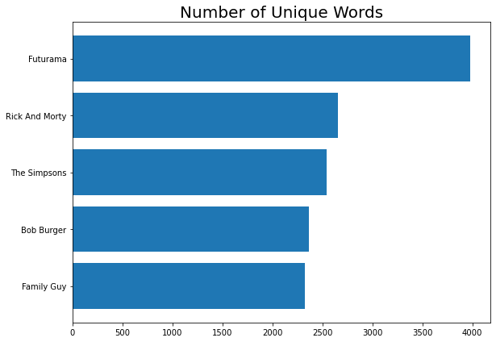

```python
y_pos = np.arange(len(data_words))

plt.subplot(1, 2, 1)
plt.barh(y_pos, data_unique_sort.unique_words, align='center')
plt.yticks(y_pos, data_unique_sort.tvshows)
plt.title('Number of Unique Words', fontsize=20)

plt.tight_layout()
plt.show()
```

## Sentiment Analysis

```python
pol = lambda x: TextBlob(x).sentiment.polarity
sub = lambda x: TextBlob(x).sentiment.subjectivity

data_clean['polarity'] = data_clean['transcript'].apply(pol)
data_clean['subjectivity'] = data_clean['transcript'].apply(sub)
data_clean['tvshow'] = data_clean['tv_show']
data_clean
```

|  | tv_show | transcript | bag | len | polarity | subjectivity | tvshow |
| --- | --- | --- | --- | --- | --- | --- | --- |
| 0 | Bob Burger | plays back chewing gene adds reverb gene gene burps what stop bob no more newspaper please my parents are gonna be here any minute i know you know... | [plays, back, chewing, gene, adds, reverb, gene, gene, burps, what, stop, bob, no, more, newspaper, please, my, parents, are, gonna, be, here, any... | 18677 | 0.127650 | 0.541060 | Bob Burger |
| 1 | Family Guy | lois singing it seems today that all you see n is violence in movies and sex on tv n but where are those good oldfashioned values n on which we u... | [lois, singing, it, seems, today, that, all, you, see, n, is, violence, in, movies, and, sex, on, tv, n, but, where, are, those, good, oldfashione... | 13950 | 0.097238 | 0.544566 | Family Guy |
| 2 | Futurama | this place was a great choice the food is amazing and such generous portions if you liked the meal just wait till you trynthese afterdinner mints ... | [this, place, was, a, great, choice, the, food, is, amazing, and, such, generous, portions, if, you, liked, the, meal, just, wait, till, you, tryn... | 16772 | 0.048442 | 0.556193 | Futurama |
| 3 | Rick And Morty | run morty do it hit the button now i cant do it rick theyre my parents and sister morty i already told you its not your family theyre clones from ... | [run, morty, do, it, hit, the, button, now, i, cant, do, it, rick, theyre, my, parents, and, sister, morty, i, already, told, you, its, not, your,... | 17047 | 0.084268 | 0.539159 | Rick And Morty |
| 4 | The Simpsons | inside homer opens an oven homer do i smell cupcakes ooh do i ever marge uhuh homer lisas making these for her teacher homer ah say no more he ... | [inside, homer, opens, an, oven, homer, do, i, smell, cupcakes, ooh, do, i, ever, marge, uhuh, homer, lisas, making, these, for, her, teacher, hom... | 13524 | 0.076635 | 0.506691 | The Simpsons |

Also, these TV Shows are quite opinionated in their own ways.